# Übungsblatt 1

Autor

Marcel Dettling

Version vom

24. Oktober 2024

## Aufgabe 1

Im File `autodistanz.rda` finden sie von 82 Männern ihr Alter und die durchschnittlich im Jahr 2014 zurückgelegte Tagesdistanz mit dem Auto. Es handelt sich dabei allesamt um Männer, die selbst ein Auto besitzen und dieses auch fahren.

```r
load("autodistanz.rda")
```

### Teilaufgabe a)

Stellen sie die Daten geeignet in einem Scatterplot dar, und legen sie einen Loess-Glätter hinein, um den Zusammenhang zwischen der Zielgrösse `distanz` und dem Prädiktor `alter` zu visualisieren.

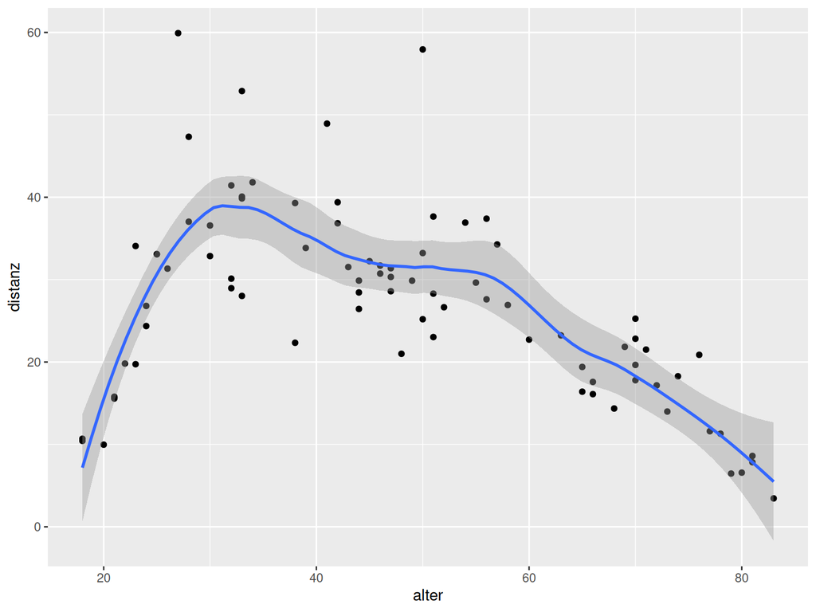

```r
library(tidyverse)
ggplot(autodistanz, aes(alter, distanz)) +
  geom_point() +
  geom_smooth(method = "loess", span = 0.5)
```

**Varianz ist heterogen verteilt. daher Log-Transformation ausprobieren.**

### Teilaufgabe b)

Verwenden sie nun anstelle des Loess-Glätters ein geeignetes Polynom, welches ihnen den Zusammenhang zwischen den beiden Grössen schätzt.

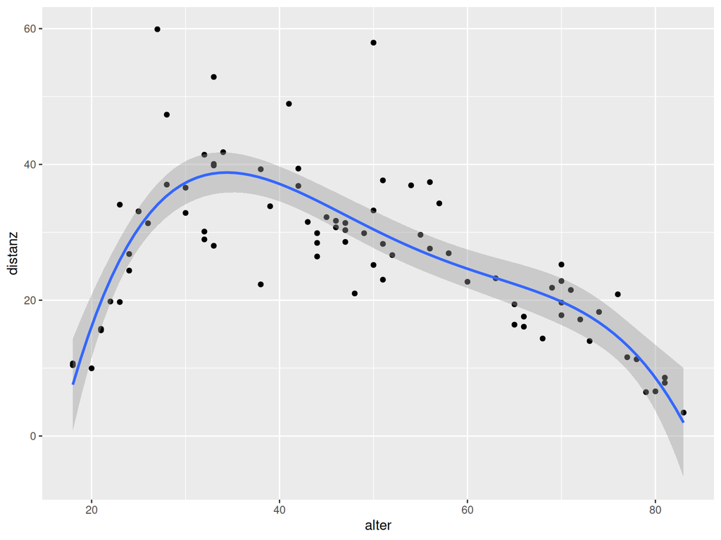

```r
library(tidyverse)
ggplot(autodistanz, aes(alter, distanz)) +
  geom_point() +
  geom_smooth(method = "lm", formula = y ~ poly(x, 4))
```

```r
fit <- lm(distanz ~ poly(alter, 4), data = autodistanz)
summary(fit)
```

```
Call:
lm(formula = distanz ~ poly(alter, 4), data = autodistanz)

Residuals:
    Min      1Q  Median      3Q     Max
-15.722  -4.010  -1.208   2.452  27.505

Coefficients:
                Estimate Std. Error t value Pr(>|t|)
(Intercept)      26.8220     0.7726  34.716  < 2e-16 ***
poly(alter, 4)1 -45.9776     6.9963  -6.572 5.32e-09 ***
poly(alter, 4)2 -60.2910     6.9963  -8.618 6.55e-13 ***
poly(alter, 4)3  27.2452     6.9963   3.894 0.000208 ***
poly(alter, 4)4 -25.4200     6.9963  -3.633 0.000502 ***
---
Signif. codes:  0 '***' 0.001 '**' 0.01 '*' 0.05 '.' 0.1 ' ' 1

Residual standard error: 6.996 on 77 degrees of freedom
Multiple R-squared:  0.6544,    Adjusted R-squared:  0.6365
F-statistic: 36.45 on 4 and 77 DF,  p-value: < 2.2e-16
```

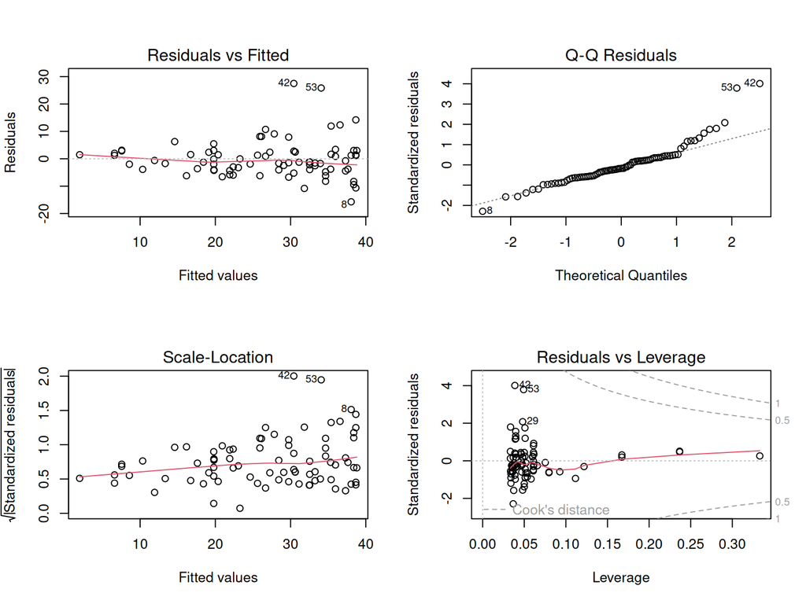

```r
par(mfrow = c(2, 2))
plot(fit)
```

### Teilaufgabe c)

Anstelle des Polynoms sollen sie nun ein Modell mit kubischen Splines anpassen. Verwenden sie dazu sowohl die Funktion `smooth.spline()` wie auch die Funktion `gam()` aus der `library(mgcv)` und plotten sie die Fits.

```
Call:
smooth.spline(x = autodistanz$alter, y = autodistanz$distanz,
    all.knots = TRUE)

Smoothing Parameter  spar= 0.6321765  lambda= 0.0002401789 (12 iterations)
Equivalent Degrees of Freedom (Df): 9.437413
Penalized Criterion (RSS): 1684.544
GCV: 49.69918
```

[output not shown]

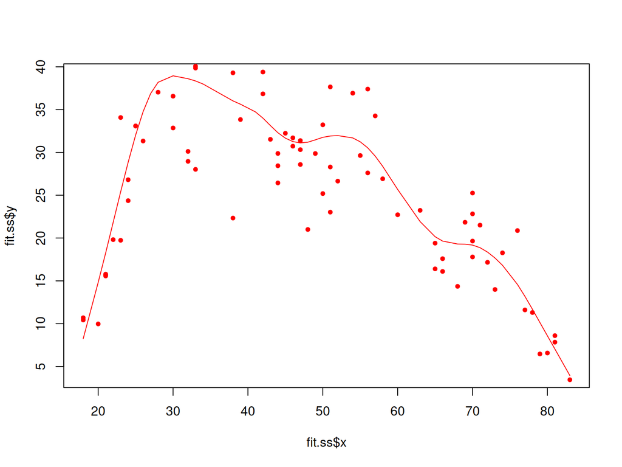

```
Family: gaussian
Link function: identity

Formula:
distanz ~ s(alter)

Parametric coefficients:
            Estimate Std. Error t value Pr(>|t|)
(Intercept)  26.8220     0.7453   35.99   <2e-16 ***
---
Signif. codes:  0 '***' 0.001 '**' 0.01 '*' 0.05 '.' 0.1 ' ' 1

Approximate significance of smooth terms:
           edf Ref.df     F p-value
s(alter) 6.669  7.786 20.55  <2e-16 ***
---
Signif. codes:  0 '***' 0.001 '**' 0.01 '*' 0.05 '.' 0.1 ' ' 1

R-sq.(adj) =  0.662   Deviance explained =   69%
GCV = 50.248  Scale est. = 45.548    n = 82
```

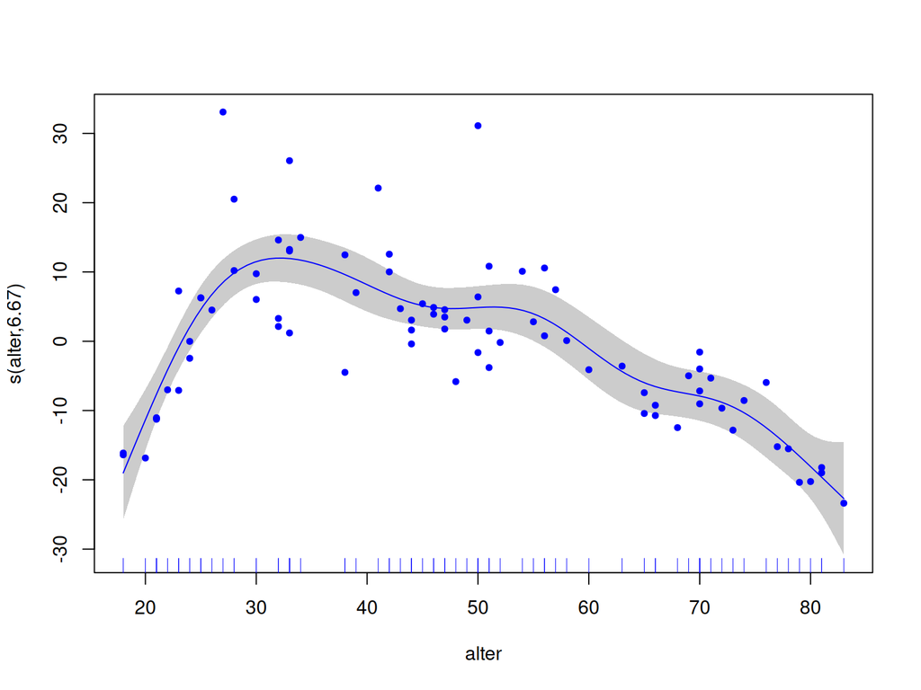

### Teilaufgabe d)

*(Advanced)* Lösen sie die Aufgabe mit Regression Splines. Setzen sie 4 Knoten, wobei die x-Werte geeignet nach Gutdünken gesetzt werden sollen. Programmieren sie dann einen stückweise konstanten Fit, einen der stückweise linear und kontinuierlich ist, sowie einen der 2x stetig differenzierbare, kubische Polynome verwendet.

## Aufgabe 2

Die Zeitreihe `spt` im File `suhre_phostot.rda` enthält monatlich gemessene Phosphatwerte aus der Suhre im Kanton Luzern. Sie sollen diese Werte als Zielgrösse verwenden. Als Prädiktor wird die Zeit der Beobachtung verwendet, welche man via `time(spt)` extrahieren kann.

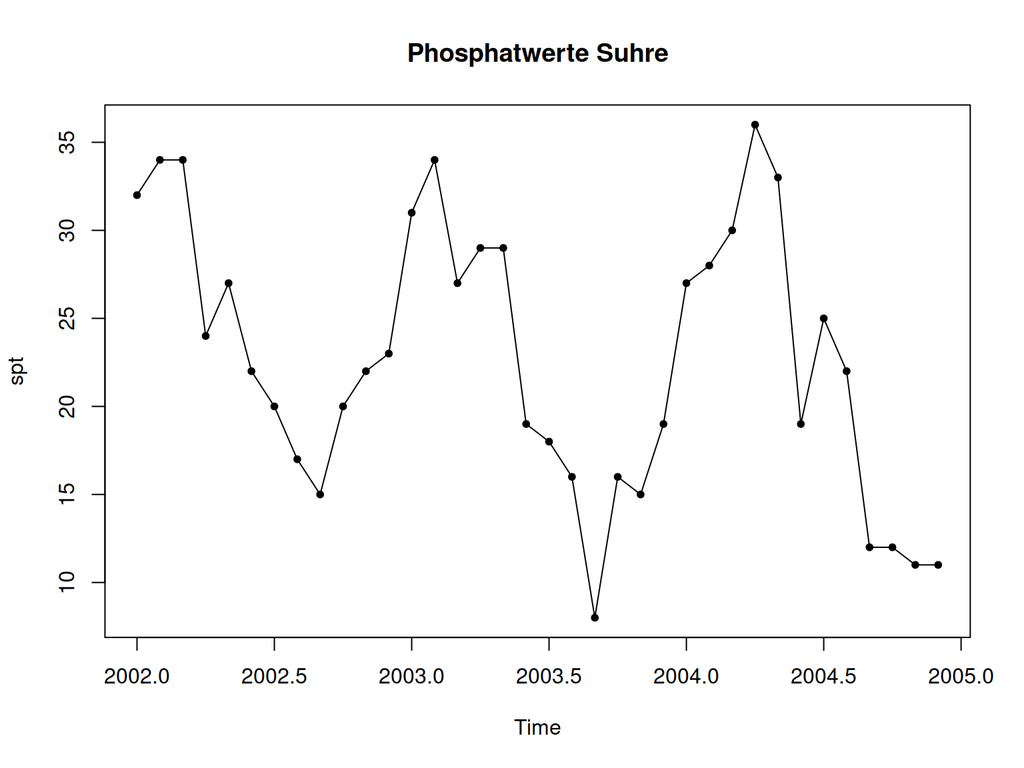

### Teilaufgabe a)

Passen sie mit der Funktion `gam()` einen Smoothing-Spline-Fit an, welcher die zeitliche Entwicklung der Phosphatwerte aufzeigt.

```
Family: gaussian
Link function: identity

Formula:
spt ~ s(time(spt))

Parametric coefficients:
            Estimate Std. Error t value Pr(>|t|)
(Intercept)  22.6944     0.5198   43.66   <2e-16 ***
---
Signif. codes:  0 '***' 0.001 '**' 0.01 '*' 0.05 '.' 0.1 ' ' 1

Approximate significance of smooth terms:
               edf Ref.df     F p-value
s(time(spt)) 8.361  8.886 20.37  <2e-16 ***
---
Signif. codes:  0 '***' 0.001 '**' 0.01 '*' 0.05 '.' 0.1 ' ' 1

R-sq.(adj) =  0.837   Deviance explained = 87.6%
GCV = 13.144  Scale est. = 9.7259    n = 36
```

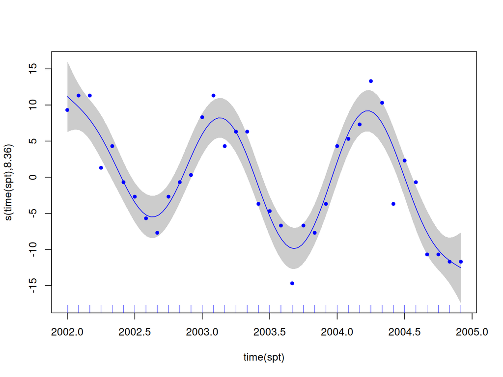

### Teilaufgabe b)

Verwenden sie stattdessen ein Modell, welches geeignete Transformationen der Zeit-Variable verwendet, um ebenfalls die zeitliche Entwicklung der Phosphatwerte anzugeben. **Hinweis:** *die Zeitreihe enthält einen linearen Trend sowie eine zyklische Saison-Komponente, welche mit einer Faktorvariable oder (besser!) mit einer harmonischen Schwingung modelliert wird.*

```
Call:
lm(formula = spt ~ time(spt) + sin(2 * pi * time(spt)) + cos(2 *
    pi * time(spt)), data = spt)

Residuals:
    Min      1Q  Median      3Q     Max
-8.7044 -2.1660 -0.2529  2.7369  7.7791

Coefficients:
                         Estimate Std. Error t value Pr(>|t|)
(Intercept)             2831.2732  1692.7075   1.673  0.10415
time(spt)                 -1.4019     0.8449  -1.659  0.10684
sin(2 * pi * time(spt))    7.8420     1.0320   7.599 1.17e-08 ***
cos(2 * pi * time(spt))    3.4357     1.0004   3.434  0.00166 **
---
Signif. codes:  0 '***' 0.001 '**' 0.01 '*' 0.05 '.' 0.1 ' ' 1

Residual standard error: 4.234 on 32 degrees of freedom
Multiple R-squared:  0.7247,    Adjusted R-squared:  0.6989
F-statistic: 28.08 on 3 and 32 DF,  p-value: 4.332e-09
```

[figure not shown]

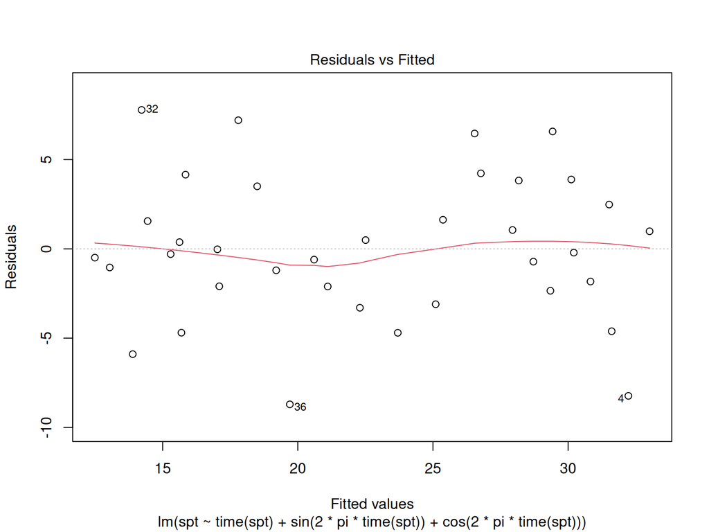

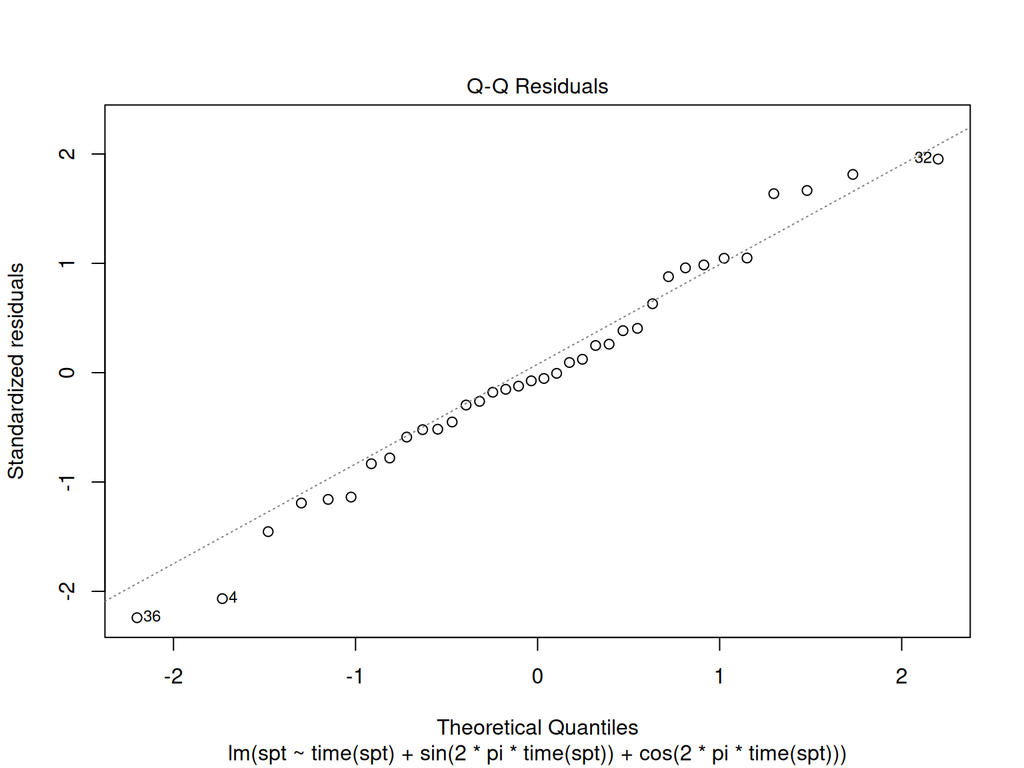

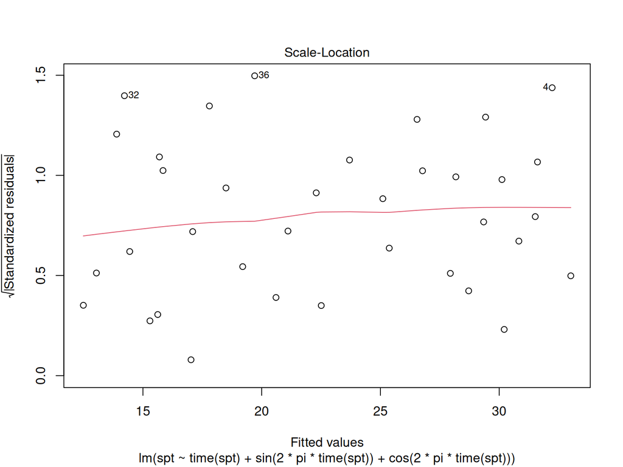

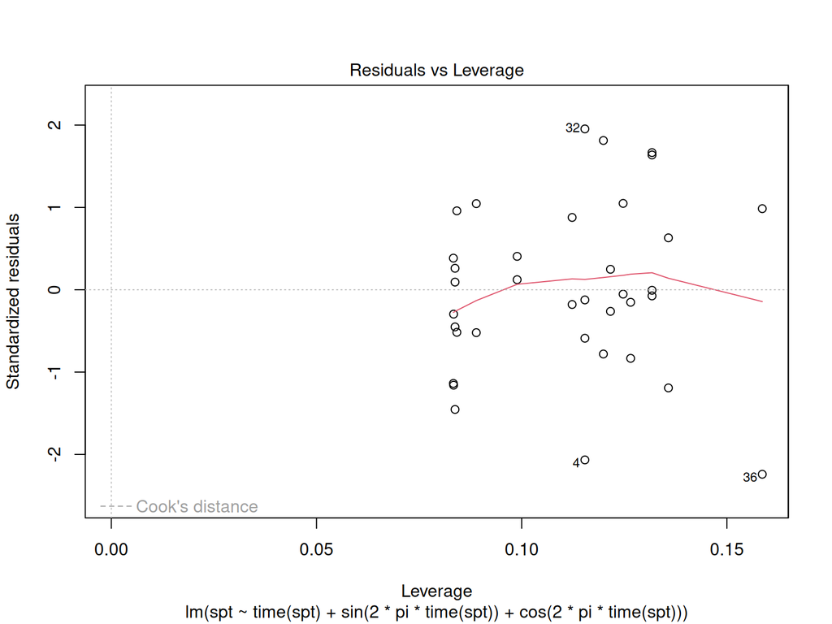